# Capstone Project

```python
# This Python 3 environment comes with many helpful analytics libraries installed
# It is defined by the kaggle/python docker image: https://github.com/kaggle/docker-python
# For example, here's several helpful packages to load in

import numpy as np # linear algebra
import pandas as pd # data processing, CSV file I/O (e.g. pd.read_csv)

# Input data files are available in the "../input/" directory.
# For example, running this (by clicking run or pressing Shift+Enter) will list all files under the input directory
cnt = 0
files = []
import os
for dirname, _, filenames in os.walk('speech_commands'):
    for filename in filenames:
        print(os.path.join(dirname, filename))
        files.append(os.path.join(dirname, filename))
        cnt += 1
print(cnt)
# Any results you write to the current directory are saved as output.
```

[output not shown]

[output cut: 64674 more lines]

[output not shown]

## Data Exploration and Preprocessing

First, let's see what type of sound files we are looking at and see let us see their waveforms.

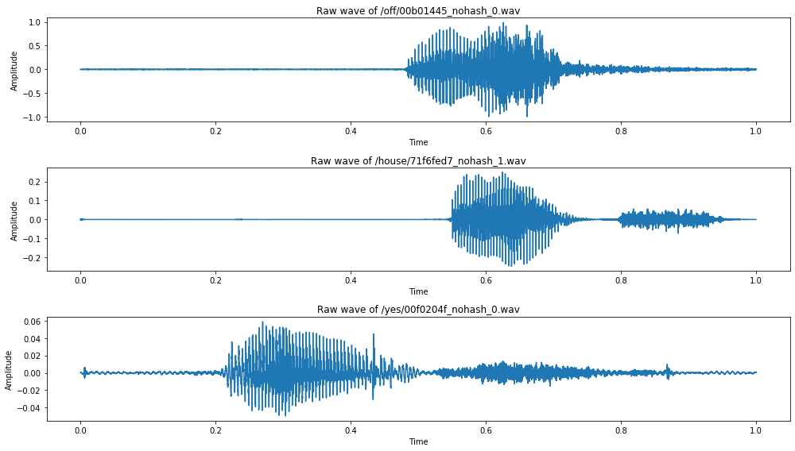

```python
import numpy as np
from scipy.io import wavfile
import matplotlib.pyplot as plt

DIR = 'speech_commands'
fns = ['/off/00b01445_nohash_0.wav',
       '/house/71f6fed7_nohash_1.wav',
       '/yes/00f0204f_nohash_0.wav']
SAMPLE_RATE = 16000

def read_wav_file(x):
    # Read wavfile using scipy wavfile.read
    _, wav = wavfile.read(x)
    # Normalize
    wav = wav.astype(np.float64) / np.iinfo(np.int16).max

    return wav

fig = plt.figure(figsize=(14, 8))
for i, fn in enumerate(fns):
    wav = read_wav_file(DIR + fn)

    ax = fig.add_subplot(3,1,i+1)
    ax.set_title('Raw wave of ' + fn)
    ax.set_ylabel('Amplitude')
    ax.set_xlabel('Time')
    ax.plot(np.linspace(0, 1, SAMPLE_RATE), wav)
fig.tight_layout()
plt.show()
```

The above visualization is easy enough to work with for most purposes. However in NLP applications, the waveforms are converted into some other form that is easier for the model to work with. Since, I will be using a CNN, a pictorial representation is going to make the life easier. So, now we compute the log spectogram from Short Time Fourer Transform to achieve just that!

```
(257, 98)
(257, 98)
(257, 98)
```

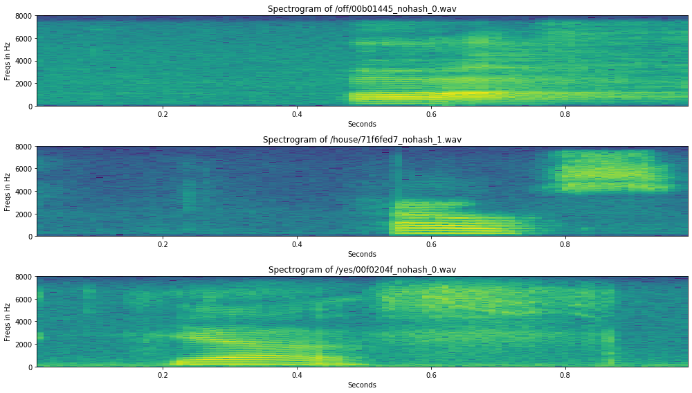

```python
from scipy.signal import stft

def log_spectrogram(wav):
    freqs, times, spec = stft(wav, SAMPLE_RATE, nperseg = 400, noverlap = 240, nfft = 512, padded = False, boundary = None)
    # Log spectrogram
    amp = np.log(np.abs(spec)+1e-10)

    return freqs, times, amp

fig = plt.figure(figsize=(14, 8))
for i, fn in enumerate(fns):
    wav = read_wav_file(DIR + fn)
    freqs, times, amp = log_spectrogram(wav)

    ax = fig.add_subplot(3,1,i+1)
    ax.imshow(amp, aspect='auto', origin='lower',
               extent=[times.min(), times.max(), freqs.min(), freqs.max()])
    ax.set_title('Spectrogram of ' + fn)
    ax.set_ylabel('Freqs in Hz')
    ax.set_xlabel('Seconds')
    print(amp.shape)
fig.tight_layout()
```

As we can see here,the STFT log spectrogram is unique for every utterance and as such will provide a good training dataset.

Now, we get for each training sample its spectogram and its label which is the name of the folder it resides in. We make an input vector X which contains the spectograms and an output vector y ehich cntains the labels.

```python
import sys
X = []
y = []
cnt = 0
for file in files[5:]:
    if file.endswith('.wav'):
        wav = read_wav_file(file)
        if len(wav) == 16000:
            freq, time, amp = log_spectrogram(wav)
            label = file.split('/')[1]
            amp = amp.reshape(amp.shape[0], amp.shape[1], 1)
            X.append(amp)
            y.append(label)
            cnt +=1
            sys.stdout.write('\r{}'.format(cnt))
            sys.stdout.flush()
```

```
33013
```

```
58249
```

Now that time to convert the named categories to one-hot encoded categories to aid in classification. This is the case because when dealing with numbers calculating loss becomes easire to compute.

```python
from sklearn.preprocessing import LabelEncoder
from keras.utils import np_utils
le = LabelEncoder()
y2=le.fit_transform(y)
classes= list(le.classes_)
y2=np_utils.to_categorical(y2, num_classes=30)
```

Let's convert the features into numpy array to pass into the neural network.

```python
X1 = np.array(X)
```

Let's separate the data into training and validation sets. Where the validation takes 30% of all data points.

```python
from sklearn.model_selection import train_test_split
X_train, X_test, y_train, y_test = train_test_split(X1, y2, test_size = 0.3, random_state = 2019)
```

```python
sz1 = X_train.shape
sz2 = X_test.shape
print(sz1)
print(sz2)
```

```
(40774, 257, 98, 1)
(17475, 257, 98, 1)
```

As you can see here. We have 40774 (70%) training sample each with shape (257, 98, 1) and 17475 (30%) validation samples with the same shape.

## Model Building

Now for the showdown! Let's build the model! It's basically made up from 4 Convolutional Layers, interspersed with Dropout to prevent overfitting. They basically serve as a feature extraction step. Then there comes 3 Dense layers that makes the decision and classify the histograms into 30 different words.

```python
from tensorflow.keras.layers import Dense, Dropout, Flatten, Conv2D, Input, MaxPooling2D
from tensorflow.keras.models import Sequential
from tensorflow.keras.callbacks import EarlyStopping, ModelCheckpoint
from tensorflow.keras import backend as K
K.clear_session()

model = Sequential()
model.add(Conv2D(32, (3,3), activation='relu', padding='same', strides=1, input_shape = X_train.shape[1:]))
model.add(MaxPooling2D((3, 3), strides=(2,2), padding='same'))
model.add(Dropout(0.3))
model.add(Conv2D(64, (3,3), activation='relu', padding='same', strides=1))
model.add(MaxPooling2D((3, 3), strides=(2,2), padding='same'))
model.add(Dropout(0.4))
model.add(Conv2D(128, (3,3), activation='relu', padding='same', strides=1))
model.add(MaxPooling2D((3, 3), strides=(2,2), padding='same'))
model.add(Dropout(0.2))
model.add(Conv2D(256, (3,3), activation='relu', padding='same', strides=1))
model.add(MaxPooling2D((3, 3), strides=(2,2), padding='same'))
model.add(Dropout(0.2))
model.add(Flatten())
model.add(Dense(64, activation = 'relu'))
model.add(Dense(128, activation = 'relu'))
model.add(Dense(30, activation = 'softmax'))

model.summary()
model.compile(optimizer='adam', loss='categorical_crossentropy', metrics=['accuracy'])
```

```
Model: "sequential"
_________________________________________________________________
Layer (type)                 Output Shape              Param #
=================================================================
conv2d (Conv2D)              (None, 257, 98, 32)       320
_________________________________________________________________
max_pooling2d (MaxPooling2D) (None, 129, 49, 32)       0
_________________________________________________________________
dropout (Dropout)            (None, 129, 49, 32)       0
_________________________________________________________________
conv2d_1 (Conv2D)            (None, 129, 49, 64)       18496
_________________________________________________________________
max_pooling2d_1 (MaxPooling2 (None, 65, 25, 64)        0
_________________________________________________________________
dropout_1 (Dropout)          (None, 65, 25, 64)        0
_________________________________________________________________
conv2d_2 (Conv2D)            (None, 65, 25, 128)       73856
_________________________________________________________________
max_pooling2d_2 (MaxPooling2 (None, 33, 13, 128)       0
_________________________________________________________________
dropout_2 (Dropout)          (None, 33, 13, 128)       0
_________________________________________________________________
conv2d_3 (Conv2D)            (None, 33, 13, 256)       295168
_________________________________________________________________
max_pooling2d_3 (MaxPooling2 (None, 17, 7, 256)        0
_________________________________________________________________
dropout_3 (Dropout)          (None, 17, 7, 256)        0
_________________________________________________________________
flatten (Flatten)            (None, 30464)             0
_________________________________________________________________
dense (Dense)                (None, 64)                1949760
_________________________________________________________________
dense_1 (Dense)              (None, 128)               8320
_________________________________________________________________
dense_2 (Dense)              (None, 30)                3870
=================================================================
Total params: 2,349,790
Trainable params: 2,349,790
Non-trainable params: 0
_________________________________________________________________
```

```python
from tensorflow.keras.callbacks import ModelCheckpoint
epochs = 500
checkpointer = ModelCheckpoint(filepath='saved_models/weights.best.from_scratch.hdf5',
                               verbose=1, save_best_only=True)
es = EarlyStopping(monitor='val_loss', mode='min', verbose=1, patience=50)
model.fit(X_train, y_train,
          validation_data=(X_test, y_test),
          epochs=epochs, batch_size=1100, callbacks=[checkpointer, es], verbose=1)
```

```
Train on 40774 samples, validate on 17475 samples
Epoch 00001: val_loss improved from inf to 3.39830, saving model to saved_models/weights.best.from_scratch.hdf5
Epoch 00002: val_loss improved from 3.39830 to 3.38799, saving model to saved_models/weights.best.from_scratch.hdf5
Epoch 00003: val_loss improved from 3.38799 to 3.29359, saving model to saved_models/weights.best.from_scratch.hdf5
Epoch 00004: val_loss improved from 3.29359 to 3.14713, saving model to saved_models/weights.best.from_scratch.hdf5
Epoch 00005: val_loss improved from 3.14713 to 2.94994, saving model to saved_models/weights.best.from_scratch.hdf5
Epoch 00006: val_loss improved from 2.94994 to 2.64710, saving model to saved_models/weights.best.from_scratch.hdf5
Epoch 00007: val_loss improved from 2.64710 to 2.33111, saving model to saved_models/weights.best.from_scratch.hdf5
Epoch 00008: val_loss improved from 2.33111 to 2.16068, saving model to saved_models/weights.best.from_scratch.hdf5
Epoch 00009: val_loss improved from 2.16068 to 2.06163, saving model to saved_models/weights.best.from_scratch.hdf5
Epoch 00010: val_loss improved from 2.06163 to 1.81530, saving model to saved_models/weights.best.from_scratch.hdf5
Epoch 00011: val_loss improved from 1.81530 to 1.75245, saving model to saved_models/weights.best.from_scratch.hdf5
Epoch 00012: val_loss improved from 1.75245 to 1.57021, saving model to saved_models/weights.best.from_scratch.hdf5
Epoch 00013: val_loss improved from 1.57021 to 1.45971, saving model to saved_models/weights.best.from_scratch.hdf5
Epoch 00014: val_loss improved from 1.45971 to 1.29136, saving model to saved_models/weights.best.from_scratch.hdf5
Epoch 00015: val_loss improved from 1.29136 to 1.19877, saving model to saved_models/weights.best.from_scratch.hdf5
Epoch 00016: val_loss improved from 1.19877 to 1.11744, saving model to saved_models/weights.best.from_scratch.hdf5
Epoch 00017: val_loss improved from 1.11744 to 1.09848, saving model to saved_models/weights.best.from_scratch.hdf5
Epoch 00018: val_loss improved from 1.09848 to 0.91549, saving model to saved_models/weights.best.from_scratch.hdf5
Epoch 00019: val_loss improved from 0.91549 to 0.89912, saving model to saved_models/weights.best.from_scratch.hdf5
Epoch 00020: val_loss improved from 0.89912 to 0.83505, saving model to saved_models/weights.best.from_scratch.hdf5
Epoch 00021: val_loss improved from 0.83505 to 0.80847, saving model to saved_models/weights.best.from_scratch.hdf5
Epoch 00022: val_loss improved from 0.80847 to 0.72002, saving model to saved_models/weights.best.from_scratch.hdf5
Epoch 00023: val_loss improved from 0.72002 to 0.68465, saving model to saved_models/weights.best.from_scratch.hdf5
Epoch 00024: val_loss improved from 0.68465 to 0.59482, saving model to saved_models/weights.best.from_scratch.hdf5
Epoch 00025: val_loss did not improve from 0.59482
Epoch 00026: val_loss improved from 0.59482 to 0.58038, saving model to saved_models/weights.best.from_scratch.hdf5
Epoch 00027: val_loss improved from 0.58038 to 0.53695, saving model to saved_models/weights.best.from_scratch.hdf5
Epoch 00028: val_loss did not improve from 0.53695
Epoch 00029: val_loss improved from 0.53695 to 0.53165, saving model to saved_models/weights.best.from_scratch.hdf5
Epoch 00030: val_loss improved from 0.53165 to 0.49666, saving model to saved_models/weights.best.from_scratch.hdf5
Epoch 00031: val_loss did not improve from 0.49666
Epoch 00032: val_loss improved from 0.49666 to 0.47904, saving model to saved_models/weights.best.from_scratch.hdf5
Epoch 00033: val_loss improved from 0.47904 to 0.45711, saving model to saved_models/weights.best.from_scratch.hdf5
Epoch 00034: val_loss improved from 0.45711 to 0.42626, saving model to saved_models/weights.best.from_scratch.hdf5
Epoch 00035: val_loss did not improve from 0.42626
Epoch 00036: val_loss did not improve from 0.42626
Epoch 00037: val_loss improved from 0.42626 to 0.39930, saving model to saved_models/weights.best.from_scratch.hdf5
Epoch 00038: val_loss improved from 0.39930 to 0.38708, saving model to saved_models/weights.best.from_scratch.hdf5
Epoch 00039: val_loss did not improve from 0.38708
```

[output cut: 84 more lines]

```
Epoch 00124: val_loss did not improve from 0.25330
Epoch 00125: val_loss did not improve from 0.25330
Epoch 00126: val_loss did not improve from 0.25330
Epoch 00127: val_loss did not improve from 0.25330
Epoch 00128: val_loss did not improve from 0.25330
Epoch 00129: val_loss did not improve from 0.25330
Epoch 00130: val_loss did not improve from 0.25330
Epoch 00131: val_loss did not improve from 0.25330
Epoch 00132: val_loss did not improve from 0.25330
Epoch 00133: val_loss did not improve from 0.25330
Epoch 00134: val_loss did not improve from 0.25330
Epoch 00135: val_loss did not improve from 0.25330
Epoch 00136: val_loss did not improve from 0.25330
Epoch 00137: val_loss did not improve from 0.25330
Epoch 00137: early stopping
```

```
<tensorflow.python.keras.callbacks.History at 0x7fa5f85849d0>
```

## Model Evaluation

As a final check. Let's check the training and validation accuracy scores, just to make sure the model did a good job at learning.

```python
from sklearn.metrics import accuracy_score
y_train_probs = model.predict(X_train)
y_valid_probs = model.predict(X_test)
y_train_pred = np.argmax(y_train_probs, axis = 1)
y_valid_pred = np.argmax(y_valid_probs, axis = 1)
y_train_true = np.argmax(y_train, axis = 1)
y_valid_true = np.argmax(y_test, axis = 1)
train_acc = accuracy_score(y_train_true, y_train_pred)
valid_acc = accuracy_score(y_valid_true, y_valid_pred)
print("The model achieved {}% in training accuracy, and {}% in validation accuracy".format(train_acc, valid_acc))
```

```
The model achieved 0.9900671996860745% in training accuracy, and 0.9324177396280401% in validation accuracy
```

There seems a sign of very minimal overfitting, if there is any to be frank. Let's try with our saved weights.

```python
from sklearn.metrics import accuracy_score
model.load_weights('saved_models/weights.best.from_scratch.hdf5')
y_train_probs = model.predict(X_train)
y_valid_probs = model.predict(X_test)
y_train_pred = np.argmax(y_train_probs, axis = 1)
y_valid_pred = np.argmax(y_valid_probs, axis = 1)
y_train_true = np.argmax(y_train, axis = 1)
y_valid_true = np.argmax(y_test, axis = 1)
train_acc = accuracy_score(y_train_true, y_train_pred)
valid_acc = accuracy_score(y_valid_true, y_valid_pred)
print("The model achieved {}% in training accuracy, and {}% in validation accuracy".format(train_acc, valid_acc))
```

```
The model achieved 0.980992789522735% in training accuracy, and 0.9324749642346208% in validation accuracy
```

There is not much difference between the two, and I believe the model did not get the chance to overfit just yet and it generalized well enough, due to the proximity between between the trainig and validation accuracies.